# Laue maps quickstart: from the scans of your experiment to orientation and grain maps

This notebook analyses a 2D map of Laue patterns (`amesh` scan) recorded at BM32, in 5 steps:

| step | what | result (in `PROCESSED_DATA`) |
| --- | --- | --- |
| 1 | choose a map in the list of the scans of your experiment |  |
| 2 | write the settings files of the analysis | `configs/peaksearch.yaml`, `configs/indexing.yaml` |
| 3 | **peak search**: find the Laue spots of every image | `corfiles/*.dat`, `*.cor` |
| 4 | **indexation**: find the orientation (and strain) of the crystal(s) at every point | `fitfiles_<material>/*.fit` |
| 5 | **maps**: quality, orientation (IPF colors), grains, misorientations (KAM, GROD) | figures |
| 6 | (option) the same analysis for a series of maps (e.g. temperatures) |  |

**How to use it**

- edit only the **SETTINGS** cell, then run the cells one after the other (`Shift + Enter`)
- messages in **red** say what to change; in **green**, all is fine
- **running the notebook again is safe**: steps already done are not computed again (their results are reloaded), nothing is deleted. Images (`RAW_DATA`) are only read
- after a change of parameters (SETTINGS or YAML files), the steps concerned are computed again automatically; the previous results are kept in folders `*_previous_<date>`
- computations run on the ESRF cluster (SLURM, e.g. `magnifix` partition) when the notebook runs on https://jupyter-slurm.esrf.fr, otherwise on this computer with all its cpus

For more control: notebooks `../peaksearch/peaksearch_map.ipynb` and `../indexation/` (they use the settings files written here).

**This notebook is part of the LaueTools package** (https://github.com/BM32ESRF/lauetools). Author: J.-S. Micha, Oct 2026

# SETTINGS

```python
# 1. your experiment: RAW_DATA folder (at ESRF: /data/visitor/<proposal>/bm32/<date>/RAW_DATA)
RAW_DATA_FOLDER = '/data/visitor/<proposal>/bm32/<date>/RAW_DATA'
SCAN_FILTER = ''           # show only the maps whose name contains this text, e.g. 'ZONE3' ('': all maps)
SCAN_INDEX = None          # None: choose the map in the menu of STEP 1; or its index in the table, e.g. 1240
MODE = 'compute'           # 'compute': analyse the map (steps already done with the same parameters are reloaded)
                           # 'show': only show the results of a map analysed before (nothing computed, files unchanged)

# 2. your sample
KEY_MATERIAL = 'MgO'       # material to index (name in the LaueTools list: MW.find_material('Mg') prints the names with 'Mg')
NB_GRAINS = 5              # max nb of grains (orientations) to find in each image

# 3. calibration and parameters
DETFILE = 'auto'           # detector calibration .det file; 'auto': the most recent one of the experiment
PSPFILE = None             # optional: .psp file of the LaueTools GUI, its values are copied once into peaksearch.yaml
PEAKSEARCH = {'IntensityThreshold': 100, 'NumberMaxofFits': 20000, 'PeakSizeRange': [0.4, 10]}            # changes of peak search parameters, e.g. {'IntensityThreshold': 300}
                           # weak and broad spots: {'IntensityThreshold': 100, 'NumberMaxofFits': 20000, 'PeakSizeRange': [0.4, 10]}
INDEXING = {'central spots indices':np.arange(25).tolist(), 'NBMAXPROBED':30}              # changes of indexation parameters, e.g. {'e_max': 22, 'MinimumNumberMatches': 8}

# 4. computer
EXECUTION = 'auto'         # 'auto': cluster (SLURM) if available, else this computer; or 'local', 'slurm'
SLURM_MACHINE = 'magnifix3'     # cluster: 'auto', 'magnifix' (192 cpus), 'magnifix2', 'magnifix3' (2 or 3 nodes of 192 cpus),
                           # 'hpc6', 'hpc7', 'hpc8', 'nice' (96 cpus)
NB_CPUS = None             # None: all cpus of this computer, or of the cluster node

# 5. advanced
OUTPUT_ROOT = None         # None: results in PROCESSED_DATA (recommended); or another folder
REDO = False               # True: compute again the steps already done (not needed after a change of parameters: detected)
```

# IMPORTS and computer

```python
import os
os.environ["OMP_NUM_THREADS"] = "1"
from pathlib import Path

import numpy as np
import matplotlib.pyplot as plt
try:
    import ipympl  # interactive plots (zoom, hover) in JupyterLab / VS Code
    %matplotlib widget
except ImportError:
    %matplotlib inline

import LaueTools.map_workflow as MW
import LaueTools.peaksearch_batch as PB
import LaueTools.indexing_batch as IB
import LaueTools.orientationclustering as OC
import LaueTools.generaltools as GT

execution = MW.environment(EXECUTION)
```

```
loading lauetools_config.json in  <inhouse path>
No user materials.yaml found. Using default materials.yaml
loading readmccd.py
-- WARNING: Missing library libtiff, Please install: pylibtiff if you need open some tiff images. However, Fabio or PIL can do the job!
-- warning: sklearn.metrics is not installed. For matchingrate.py module, it could be useful... but not necessary
-- WARNING: module Image or PIL is not installed, but only used for templateimagematching
hostname = hpc5-0501
machine: hpc5-0501, 10 cpus available for this notebook
cluster (SLURM): available
-> computations will run on the cluster (SLURM)
```

# STEP 1: choose a map

The table lists the 2D maps of the experiment (from the BLISS `.h5` file of `RAW_DATA_FOLDER`):

- `images`: image files found / expected (an interrupted scan has fewer images; `end` is then not `SUCCESS`)
- `done`: results already in `PROCESSED_DATA` (`peaks`: peak search, `fit:MgO`: indexation with MgO)

Choose the map in the menu below the table, then run the next cell.

```python
logfile = MW.find_logfile(RAW_DATA_FOLDER)
maps = MW.list_maps(logfile, contains=SCAN_FILTER, output_root=OUTPUT_ROOT)
MW.show_maps(maps)
```

```
75 maps found in <proposal>_bm32.h5 (7 s)
```

| index | dataset | start | hours | map | images | detector | end | done | command |
| --- | --- | --- | --- | --- | --- | --- | --- | --- | --- |
| 91 | _p3_2 | 2026-09-15 16:19 | 0.02 | 21 x 21 | 48/441 | EIGER_4MCdTe | USER_ABORT |  | amesh yech -15.30416 -15.20416 20 xech -3.19641 -3.09641 20 0.3 |
| 92 | _p3_3 | 2026-09-15 16:21 | 0.07 | 21 x 21 | 252/441 | EIGER_4MCdTe | USER_ABORT |  | amesh yech -15.30416 -15.20416 20 xech -3.19641 -3.09641 20 0.3 |
| 98 | _p2_longexpo_8 | 2026-09-15 17:59 | 0.07 | 13 x 13 | 169/169 | EIGER_4MCdTe | SUCCESS |  | amesh yech -14.26392 -14.25792 12 xech -3.16192 -3.15592 12 1 |
| 103 | _RT_fishing_p5map2D_1 | 2026-09-15 19:58 | 0.07 | 151 x 151 | 206/22801 | EIGER_4MCdTe | USER_ABORT |  | amesh yech -14.37810 -13.37810 150 xech -5.22748 -4.22748 150 0.5 |
| 104 | _RT_fishing_p5_map2D_1 | 2026-09-15 20:05 | 0.05 | 151 x 151 | 152/22801 | EIGER_4MCdTe | USER_ABORT |  | amesh yech -14.37810 -13.37810 150 xech -5.22748 -4.22748 150 0.5 |
| 105 | _RT_fishing_p5_Map2D_1 | 2026-09-15 20:10 | 0.05 | 151 x 151 | 154/22801 | EIGER_4MCdTe | USER_ABORT |  | amesh yech -14.37810 -13.37810 150 xech -5.22748 -4.22748 150 0.5 |
| 106 | _RT_fishing_p5_Map2D_0002_1 | 2026-09-15 20:15 | 7.82 | 151 x 151 | 22801/22801 | EIGER_4MCdTe | SUCCESS |  | amesh yech -14.37810 -13.37810 150 xech -5.22748 -4.22748 150 0.5 |
| 107 | _RT_fishing_p2_Map2D_1 | 2026-09-16 04:04 | 6.08 | 151 x 151 | 17311/22801 | EIGER_4MCdTe | USER_ABORT |  | amesh yech -14.76092 -13.76092 150 xech -3.64892 -2.64892 150 0.5 |
| 108 | _p3_fishing_1 | 2026-09-16 12:20 | 0.00 | 101 x 101 | ?/10201 | ? | USER_ABORT |  | amesh yech -6.36654 -6.26654 100 xech 1.01763 1.11763 100 0.5 |
| 109 | _p3_fishing_2 | 2026-09-16 12:24 | 0.84 | 51 x 51 | 2601/2601 | EIGER_4MCdTe | SUCCESS |  | amesh yech -6.36654 -6.26654 50 xech 1.01763 1.11763 50 0.5 |
| 110 | _p3_fishing_3 | 2026-09-16 14:28 | 0.00 | 26 x 26 | 11/676 | EIGER_4MCdTe | USER_ABORT |  | amesh yech -6.34316 -6.14316 25 xech 2.12781 2.32781 25 0.5 |
| 111 | _p5_fishing_1 | 2026-09-16 14:29 | 0.24 | 26 x 26 | 676/676 | EIGER_4MCdTe | SUCCESS |  | amesh yech -6.34316 -6.14316 25 xech 2.12781 2.32781 25 0.5 |
| 112 | _p5_fishing_2 | 2026-09-16 16:28 | 0.24 | 26 x 26 | 676/676 | EIGER_4MCdTe | SUCCESS |  | amesh yech -6.41300 -6.21300 25 xech 1.98580 2.18580 25 0.5 |
| 120 | _p3_fishing_larger_1 | 2026-09-16 18:56 | 0.24 | 26 x 26 | 676/676 | EIGER_4MCdTe | SUCCESS |  | amesh yech -6.46654 -6.26654 25 xech 0.91763 1.11763 25 0.5 |
| 121 | _p3_fishing_larger_2 | 2026-09-16 19:18 | 0.85 | 51 x 51 | 2601/2601 | EIGER_4MCdTe | SUCCESS |  | amesh yech -6.43825 -6.28825 50 xech 0.95686 1.10686 50 0.5 |
| 186 | _montee_500_5 | 2026-09-16 22:51 | 6.84 | 151 x 151 | 22801/22801 | EIGER_4MCdTe | SUCCESS | peaks | amesh yech -6.43556 -6.28556 150 xech 0.94696 1.09696 150 0.5 |
| 220 | _map_2D_p7_MgO_Fe_800_1 | 2026-09-17 10:56 | 0.80 | 51 x 51 | 2601/2601 | EIGER_4MCdTe | SUCCESS | peaks, fit:MgO, fit:MgO_10grains_magnifix3, fit:MgO_2grains_magnif... | amesh yech -6.43556 -6.28556 50 xech 0.94557 1.09557 50 0.5 |
| 247 | _map_2D_p7_MgO_Fe_1000_1 | 2026-09-17 12:11 | 0.77 | 51 x 51 | 2601/2601 | EIGER_4MCdTe | SUCCESS | peaks, fit:MgO_2grains | amesh yech -6.43556 -6.28556 50 xech 0.93013 1.08013 50 0.5 |
| 291 | _map_2D_p7_MgO_Fe_1200_1 | 2026-09-17 14:41 | 0.78 | 51 x 51 | 2601/2601 | EIGER_4MCdTe | SUCCESS | peaks, fit:MgO | amesh yech -6.46740 -6.31740 50 xech 0.90036 1.05036 50 0.5 |
| 303 | _1 | 2026-09-17 16:40 | 0.77 | 51 x 51 | 2601/2601 | EIGER_4MCdTe | SUCCESS |  | amesh yech -6.46740 -6.31740 50 xech 0.90120 1.05120 50 0.5 |
| 326 | _map_2D_p7_MgO_Fe_1300_1 | 2026-09-17 18:16 | 0.78 | 51 x 51 | 2601/2601 | EIGER_4MCdTe | SUCCESS | peaks, fit:MgO | amesh yech -6.46740 -6.31740 50 xech 0.90414 1.05414 50 0.5 |
| 338 | _map_2D_p7_MgO_Fe_down_1200_1 | 2026-09-17 19:30 | 0.78 | 51 x 51 | 2601/2601 | EIGER_4MCdTe | SUCCESS |  | amesh yech -6.45678 -6.30678 50 xech 0.92623 1.07623 50 0.5 |
| 351 | _map_2D_p7_MgO_Fe_down_1100_1 | 2026-09-17 20:47 | 0.77 | 51 x 51 | 2601/2601 | EIGER_4MCdTe | SUCCESS |  | amesh yech -6.45678 -6.30678 50 xech 0.92611 1.07611 50 0.5 |
| 363 | _map_2D_p7_MgO_Fe_down_1000_1 | 2026-09-17 21:48 | 0.76 | 51 x 51 | 2601/2601 | EIGER_4MCdTe | SUCCESS |  | amesh yech -6.45678 -6.30678 50 xech 0.92517 1.07517 50 0.5 |
| 369 | _map_2D_p7_MgO_Fe_down_900_1 | 2026-09-17 23:20 | 0.01 | 51 x 51 | 20/2601 | EIGER_4MCdTe | USER_ABORT |  | amesh yech -6.45678 -6.30678 50 xech 0.92516 1.07516 50 0.5 |
| 384 | _map_2D_p7_MgO_Fe_down_900_0002_1 | 2026-09-17 23:34 | 0.76 | 51 x 51 | 2601/2601 | EIGER_4MCdTe | SUCCESS |  | amesh yech -6.46915 -6.31915 50 xech 0.92830 1.07830 50 0.5 |
| 401 | _map_2D_p7_MgO_Fe_down_800_1 | 2026-09-18 00:29 | 0.77 | 51 x 51 | 2601/2601 | EIGER_4MCdTe | SUCCESS |  | amesh yech -6.48798 -6.33798 50 xech 0.92711 1.07711 50 0.5 |
| 421 | _map_2D_p7_MgO_Fe_down_700_1 | 2026-09-18 01:52 | 0.77 | 51 x 51 | 2601/2601 | EIGER_4MCdTe | SUCCESS |  | amesh yech -6.48618 -6.33618 50 xech 0.93938 1.08938 50 0.5 |
| 438 | _map_2D_p7_MgO_Fe_down_600_1 | 2026-09-18 02:47 | 0.77 | 51 x 51 | 2601/2601 | EIGER_4MCdTe | SUCCESS |  | amesh yech -6.48539 -6.33539 50 xech 0.93746 1.08746 50 0.5 |
| 455 | _map_2D_p7_MgO_Fe_down_500_1 | 2026-09-18 03:43 | 0.77 | 51 x 51 | 2601/2601 | EIGER_4MCdTe | SUCCESS |  | amesh yech -6.49916 -6.34916 50 xech 0.93760 1.08760 50 0.5 |
| 512 | _map_2D_p7_MgO_Fe_down_50_1 | 2026-09-18 05:02 | 0.77 | 51 x 51 | 2601/2601 | EIGER_4MCdTe | SUCCESS |  | amesh yech -6.51471 -6.36471 50 xech 1.22808 1.37808 50 0.5 |
| 525 | _map_2D_p7_MgO_Fe_down_50_0002_1 | 2026-09-18 09:09 | 0.77 | 51 x 51 | 2601/2601 | EIGER_4MCdTe | SUCCESS |  | amesh yech -6.49811 -6.34811 50 xech 0.91875 1.06875 50 0.5 |
| 624 | _map_2D_p7_MgO_Fe_cycle_up_1250_1 | 2026-09-18 12:08 | 0.78 | 51 x 51 | 2601/2601 | EIGER_4MCdTe | SUCCESS |  | amesh yech -6.49810 -6.34810 50 xech 0.91839 1.06839 50 0.5 |
| 640 | _map_2D_p7_MgO_Fe_cycle_down_1100_1 | 2026-09-18 13:29 | 0.78 | 51 x 51 | 2601/2601 | EIGER_4MCdTe | SUCCESS |  | amesh yech -6.49810 -6.34810 50 xech 0.92595 1.07595 50 0.5 |
| 661 | _map_2D_p7_MgO_Fe_cycle_down_900_1 | 2026-09-18 14:41 | 0.78 | 51 x 51 | 2601/2601 | EIGER_4MCdTe | SUCCESS |  | amesh yech -6.51912 -6.36912 50 xech 0.94233 1.09233 50 0.5 |
| 686 | _map_2D_p7_MgO_Fe_cycle_down_700_1 | 2026-09-18 15:47 | 0.78 | 51 x 51 | 2601/2601 | EIGER_4MCdTe | SUCCESS |  | amesh yech -6.53113 -6.38113 50 xech 0.95577 1.10577 50 0.5 |
| 711 | _map_2D_p7_MgO_Fe_cycle_down_500_1 | 2026-09-18 16:48 | 0.78 | 51 x 51 | 2601/2601 | EIGER_4MCdTe | SUCCESS |  | amesh yech -6.53464 -6.38464 50 xech 0.95793 1.10793 50 0.5 |
| 760 | _map_2D_p7_MgO_Fe_cycle_down_50_1 | 2026-09-18 18:09 | 0.78 | 51 x 51 | 2601/2601 | EIGER_4MCdTe | SUCCESS |  | amesh yech -6.51806 -6.36806 50 xech 0.92923 1.07923 50 0.5 |
| 765 | _ZONE2_fluo_map_zone2_1 | 2026-09-18 19:07 | 0.84 | 51 x 51 | 2601/2601 | EIGER_4MCdTe | SUCCESS |  | amesh yech -6.29427 -5.89427 50 xech 0.23065 0.63065 50 0.5 |
| 766 | _ZONE2_search_cristal_1 | 2026-09-18 22:04 | 0.22 | 26 x 26 | 676/676 | EIGER_4MCdTe | SUCCESS |  | amesh yech -6.30600 -6.10600 25 xech 0.17100 0.37100 25 0.5 |
| 767 | _ZONE2_search_cristal_2 | 2026-09-18 22:18 | 0.23 | 26 x 26 | 676/676 | EIGER_4MCdTe | SUCCESS |  | amesh yech -6.35892 -6.05892 25 xech 0.21764 0.41764 25 0.5 |
| 773 | _ZONE2_map_2D_p8_MgO_Fe_RT_1 | 2026-09-18 22:57 | 0.43 | 51 x 26 | 1326/1326 | EIGER_4MCdTe | SUCCESS |  | amesh yech -6.33759 -5.93759 50 xech 0.23823 0.43823 25 0.5 |
| 793 | _ZONE2_map_2D_p8_MgO_Fe_500_up_1 | 2026-09-18 23:51 | 6.56 | 151 x 76 | 11476/11476 | EIGER_4MCdTe | SUCCESS |  | amesh yech -6.36274 -5.96274 150 xech 0.21483 0.41483 75 1.5 |
| 810 | _ZONE2_map_2D_p8_MgO_Fe_800_up_1 | 2026-09-19 09:31 | 0.90 | 76 x 38 | 2888/2888 | EIGER_4MCdTe | SUCCESS |  | amesh yech -6.37534 -5.97534 75 xech 0.23014 0.43014 37 0.5 |
| 822 | _ZONE2_map_2D_p8_MgO_Fe_1000_up_1 | 2026-09-19 10:50 | 0.03 | 76 x 33 | 108/2508 | EIGER_4MCdTe | USER_ABORT |  | amesh yech -6.39001 -5.99001 75 xech 0.20111 0.37111 32 0.5 |
| 824 | _ZONE2_map_2D_p8_MgO_Fe_1000_up_3 | 2026-09-19 10:55 | 0.83 | 76 x 35 | 2660/2660 | EIGER_4MCdTe | SUCCESS |  | amesh yech -6.39001 -5.99001 75 xech 0.20163 0.38163 34 0.5 |
| 855 | _ZONE2_map_2D_p8_MgO_Fe_1250_up_1 | 2026-09-19 12:17 | 0.83 | 76 x 35 | 2660/2660 | EIGER_4MCdTe | SUCCESS |  | amesh yech -6.46932 -6.06932 75 xech 0.22234 0.40234 34 0.5 |
| 868 | _ZONE2_map_2D_p8_MgO_Fe_1200_down_1 | 2026-09-19 13:35 | 0.83 | 76 x 35 | 2660/2660 | EIGER_4MCdTe | SUCCESS |  | amesh yech -6.49284 -6.09284 75 xech 0.22926 0.40926 34 0.5 |
| 885 | _ZONE2_map_2D_p8_MgO_Fe_1100_down_1 | 2026-09-19 14:45 | 0.80 | 76 x 35 | 2660/2660 | EIGER_4MCdTe | SUCCESS |  | amesh yech -6.52102 -6.12102 75 xech 0.23579 0.41579 34 0.5 |
| 900 | _ZONE2_map_2D_p8_MgO_Fe_1000_down_1 | 2026-09-19 15:43 | 0.83 | 76 x 35 | 2660/2660 | EIGER_4MCdTe | SUCCESS |  | amesh yech -6.55998 -6.15998 75 xech 0.24484 0.42484 34 0.5 |
| 915 | _ZONE2_map_2D_p8_MgO_Fe_900_down_1 | 2026-09-19 16:43 | 0.83 | 76 x 35 | 2660/2660 | EIGER_4MCdTe | SUCCESS |  | amesh yech -6.57928 -6.17928 75 xech 0.24517 0.42517 34 0.5 |
| 930 | _ZONE2_map_2D_p8_MgO_Fe_800_down_1 | 2026-09-19 17:43 | 0.84 | 76 x 35 | 2660/2660 | EIGER_4MCdTe | SUCCESS |  | amesh yech -6.62979 -6.22979 75 xech 0.23368 0.41368 34 0.5 |
| 946 | _ZONE2_map_2D_p8_MgO_Fe_700_down_1 | 2026-09-19 18:49 | 0.83 | 76 x 35 | 2660/2660 | EIGER_4MCdTe | SUCCESS |  | amesh yech -6.67692 -6.27692 75 xech 0.25160 0.43160 34 0.5 |
| 961 | _ZONE2_map_2D_p8_MgO_Fe_600_down_1 | 2026-09-19 19:49 | 0.83 | 76 x 35 | 2660/2660 | EIGER_4MCdTe | SUCCESS |  | amesh yech -6.72466 -6.32466 75 xech 0.25261 0.43261 34 0.5 |
| 976 | _ZONE2_map_2D_p8_MgO_Fe_500_down_1 | 2026-09-19 20:48 | 0.84 | 76 x 35 | 2660/2660 | EIGER_4MCdTe | SUCCESS |  | amesh yech -6.75560 -6.35560 75 xech 0.25604 0.43604 34 0.5 |
| 1027 | _ZONE2_map_2D_p8_MgO_Fe_50_down_1 | 2026-09-19 22:13 | 0.82 | 76 x 35 | 2660/2660 | EIGER_4MCdTe | SUCCESS |  | amesh yech -6.79826 -6.39826 75 xech 0.20696 0.38696 34 0.5 |
| 1032 | _LARGE_FLUO_MAP_FlUO_X_MAP_1 | 2026-09-19 23:13 | 6.29 | 76 x 251 | 19076/19076 | EIGER_4MCdTe | SUCCESS |  | amesh yech -6.79811 -6.04811 75 xech -0.37229 2.12771 250 0.5 |
| 1037 | fishing_p9_z3_map_fluo_p9_z3_1 | 2026-09-20 09:41 | 0.54 | 41 x 41 | 1681/1681 | EIGER_4MCdTe | SUCCESS |  | amesh yech -6.45707 -6.13707 40 xech -0.46387 -0.14387 40 0.5 |
| 1038 | fishing_p9_z3_map_fluo_p9_z3_smaller_1 | 2026-09-20 10:29 | 0.30 | 31 x 31 | 961/961 | EIGER_4MCdTe | SUCCESS |  | amesh yech -6.37207 -6.22207 30 xech -0.37887 -0.22887 30 0.5 |
| 1089 | _ZONE3_map_2D_p9_MgO_Fe_500_up_1 | 2026-09-20 11:33 | 0.30 | 31 x 31 | 961/961 | EIGER_4MCdTe | SUCCESS |  | amesh yech -6.35402 -6.20402 30 xech -0.38504 -0.23504 30 0.5 |
| 1122 | _ZONE3_map_2D_p9_MgO_Fe_800_up_1 | 2026-09-20 12:19 | 0.30 | 31 x 31 | 961/961 | EIGER_4MCdTe | SUCCESS |  | amesh yech -6.35402 -6.20402 30 xech -0.39166 -0.24166 30 0.5 |
| 1149 | _ZONE3_map_2D_p9_MgO_Fe_1000_up_1 | 2026-09-20 12:53 | 0.30 | 31 x 31 | 961/961 | EIGER_4MCdTe | SUCCESS |  | amesh yech -6.35401 -6.20401 30 xech -0.40058 -0.25058 30 0.5 |
| 1174 | _ZONE3_map_2D_p9_MgO_Fe_1200_up_1 | 2026-09-20 13:28 | 0.30 | 31 x 31 | 961/961 | EIGER_4MCdTe | SUCCESS |  | amesh yech -6.35360 -6.20360 30 xech -0.40643 -0.25643 30 0.5 |
| 1189 | _ZONE3_map_2D_p9_MgO_Fe_1250_up_1 | 2026-09-20 14:09 | 0.29 | 31 x 31 | 961/961 | EIGER_4MCdTe | SUCCESS |  | amesh yech -6.35868 -6.20868 30 xech -0.40663 -0.25663 30 0.5 |
| 1202 | _ZONE3_map_2D_p9_MgO_Fe_1200_down_1 | 2026-09-20 14:49 | 0.30 | 31 x 31 | 961/961 | EIGER_4MCdTe | SUCCESS |  | amesh yech -6.35868 -6.20868 30 xech -0.40376 -0.25376 30 0.5 |
| 1221 | _ZONE3_map_2D_p9_MgO_Fe_1100_down_1 | 2026-09-20 15:37 | 1.63 | 61 x 61 | 3721/3721 | EIGER_4MCdTe | SUCCESS |  | amesh yech -6.35360 -6.20360 60 xech -0.39593 -0.24593 60 1.0 |
| 1240 | _ZONE3_map_2D_p9_MgO_Fe_1000_down_1 | 2026-09-20 17:25 | 1.63 | 61 x 61 | 3721/3721 | EIGER_4MCdTe | SUCCESS |  | amesh yech -6.35361 -6.20361 60 xech -0.38376 -0.23376 60 1.0 |
| 1259 | _ZONE3_map_2D_p9_MgO_Fe_900_down_1 | 2026-09-20 19:19 | 1.63 | 61 x 61 | 3721/3721 | EIGER_4MCdTe | SUCCESS |  | amesh yech -6.35401 -6.20401 60 xech -0.38084 -0.23084 60 1.0 |
| 1278 | _ZONE3_map_2D_p9_MgO_Fe_800_down_1 | 2026-09-20 21:08 | 1.63 | 61 x 61 | 3721/3721 | EIGER_4MCdTe | SUCCESS |  | amesh yech -6.35401 -6.20401 60 xech -0.34239 -0.19239 60 1.0 |
| 1306 | _ZONE3_map_2D_p9_MgO_Fe_700_down_1 | 2026-09-20 23:23 | 0.44 | 61 x 61 | 1023/3721 | EIGER_4MCdTe | FAILURE |  | amesh yech -6.35402 -6.20402 60 xech -0.36851 -0.21851 60 1.0 |
| 1307 | _ZONE3_map_2D_p9_MgO_Fe_700_down_0002_1 | 2026-09-21 00:24 | 1.11 | 61 x 61 | 3721/3721 | EIGER_4MCdTe | SUCCESS |  | amesh yech -6.35401 -6.20401 60 xech -0.36851 -0.21851 60 0.5 |
| 1326 | _ZONE3_map_2D_p9_MgO_Fe_600_down_1 | 2026-09-21 01:56 | 1.11 | 61 x 61 | 3721/3721 | EIGER_4MCdTe | SUCCESS |  | amesh yech -6.35401 -6.20401 60 xech -0.36927 -0.21927 60 0.5 |
| 1335 | _ZONE3_map_2D_p9_MgO_Fe_500_down_1 | 2026-09-21 03:18 | 0.30 | 31 x 31 | 961/961 | EIGER_4MCdTe | SUCCESS |  | amesh yech -6.35401 -6.20401 30 xech -0.36524 -0.21524 30 0.5 |
| 1363 | _ZONE3_map_2D_p9_MgO_Fe_50_down_1 | 2026-09-21 03:59 | 0.30 | 31 x 31 | 961/961 | EIGER_4MCdTe | SUCCESS |  | amesh yech -6.33417 -6.18417 30 xech -0.37629 -0.22629 30 0.5 |
| 1366 | _ZONE3_map_2D_p9_MgO_Fe_50_down_0002_1 | 2026-09-21 04:25 | 1.63 | 61 x 61 | 3721/3721 | EIGER_4MCdTe | SUCCESS | peaks | amesh yech -6.33417 -6.18417 60 xech -0.37629 -0.22629 60 1.0 |

```python
selector = MW.ScanSelector(maps, SCAN_INDEX)
```

```
[interactive widget (ipywidgets)]
```

```python
info = MW.scan_info(maps, selector.index, OUTPUT_ROOT)

print(f"map {info['index']}: {info['name']}")
print(f"  command   : {info['command']}")
print(f"  map       : {info['mapdims'][0]} x {info['mapdims'][1]} points, steps {info['stepsizes']} micron "
      f"(fast motor {info['fast_motor']}, slow motor {info['slow_motor']})")
print(f"  detector  : {info['CCDLabel']}, images {info['image_folder']}/{info['prefix']}{'#' * info['nbdigits']}{info['suffix']}")
print(f"  results in: {info['workdir']}")
if maps.loc[info['index'], 'done']:
    GT.printgreen(f"results exist for this map: {maps.loc[info['index'], 'done']}  (MODE = 'show' to only see them)")
if maps.loc[info['index'], 'end'] != 'SUCCESS':
    GT.printyellow(f"this scan ended with {maps.loc[info['index'], 'end']}: some images may be missing")
```

```
map 303: <dataset>_1
  command   : amesh yech -6.46740 -6.31740 50 xech 0.90120 1.05120 50 0.5
  map       : 51 x 51 points, steps [3.0, 3.0] micron (fast motor yech, slow motor xech)
  detector  : EIGER_4MCdTe, images /data/visitor/<proposal>/bm32/<date>/RAW_DATA/<sample>/<dataset>/scan0001/eiger4m_####.h5
  results in: /data/visitor/<proposal>/bm32/<date>/PROCESSED_DATA/<sample>/<dataset>/scan0001
```

# STEP 2: settings files

The settings of the analysis are written in two YAML files in the results folder (printed below): `configs/peaksearch.yaml` and `configs/indexing.yaml`. They are the only reference of the parameters (with comments) and can be edited by hand (then run this cell again). Parameters of `PEAKSEARCH`, `INDEXING` and `PSPFILE` (SETTINGS) are written in these files each time this cell runs.

With `MODE = 'show'`, the files of the map are only read (unchanged).

**Check the calibration file**: it must be the one of the detector position of this experiment.

```python
show_only = MODE == 'show'
if show_only:
    pcfg, icfg = MW.make_configs(info, KEY_MATERIAL, None, update=False)
# calibration file
elif DETFILE == 'auto':
    detfiles = MW.find_detfiles(RAW_DATA_FOLDER)
    if not detfiles:
        raise FileNotFoundError('no .det calibration file found in the experiment: set DETFILE in SETTINGS')
    detfile = detfiles[0]
    print('calibration files of the experiment (most recent first):')
    for f in detfiles[:10]:
        print(f'   {"->" if f == detfile else "  "} {f}')
else:
    detfile = Path(DETFILE)

if not show_only:
    # peak search parameters: in peaksearch.yaml (defaults of the detector, then your changes)
    if PSPFILE is None:
        for f in MW.find_pspfiles(info['image_folder'])[:3]:
            print(f'(a .psp file of the LaueTools GUI exists for this scan: PSPFILE = {str(f)!r} copies its values in peaksearch.yaml)')
    else:
        print('values of', PSPFILE, 'copied in peaksearch.yaml')
    pcfg, icfg = MW.make_configs(info, KEY_MATERIAL, detfile, pspfile=PSPFILE, peaksearch=PEAKSEARCH,
                                 indexing={'nbGrainstoFind': NB_GRAINS, **INDEXING})
print()
PB.print_config(pcfg)
PB.check_config(pcfg)
```

```
calibration files of the experiment (most recent first):
   -> /data/visitor/<proposal>/bm32/<date>/RAW_DATA/<sample>/<dataset>/scan0001/calibGe001_<sample>_RT_mardi.det
peak search configuration: /data/visitor/<proposal>/bm32/<date>/PROCESSED_DATA/<sample>/<dataset>/scan0001/configs/peaksearch.yaml
  indexing: dict_indexrefine: central spots indices: [0, 1, 2, 3, 4, 5, 6, 7, 8, 9] -> [0, 1, 2, 3, 4, 5, 6, 7, 8, 9, 10, 11, 12, 13, 14, 15, 16, 17, 18, 19, 20, 21, 22, 23, 24]
  indexing: dict_indexrefine: NBMAXPROBED: 25 -> 30
configuration written: /data/visitor/<proposal>/bm32/<date>/PROCESSED_DATA/<sample>/<dataset>/scan0001/configs/indexing.yaml

---- <dataset>_1 ----  (/data/visitor/<proposal>/bm32/<date>/PROCESSED_DATA/<sample>/<dataset>/scan0001/configs/peaksearch.yaml)
images:      /data/visitor/<proposal>/bm32/<date>/RAW_DATA/<sample>/<dataset>/scan0001/eiger4m_####.h5
peak lists:  /data/visitor/<proposal>/bm32/<date>/PROCESSED_DATA/<sample>/<dataset>/scan0001/corfiles/eiger4m_####.dat and .cor
map:         mapdims (fast, slow) = (51, 51), motors (yech, xech)
detector:    EIGER_4MCdTe, calibration /data/visitor/<proposal>/bm32/<date>/RAW_DATA/<sample>/<dataset>/scan0001/calibGe001_<sample>_RT_mardi.det
peaksearch:  method 0, IntensityThreshold 100, background auto, boxsize 15, PeakSizeRange [0.4, 10]
2601 images found in /data/visitor/<proposal>/bm32/<date>/RAW_DATA/<sample>/<dataset>/scan0001
Configuration OK
```

```
True
```

# STEP 3: PEAK SEARCH

## test on one image

The parameters are printed first: their names can be used in `PEAKSEARCH` (SETTINGS). Look at the image: the green crosses should be on the Laue spots.

- spots without cross: decrease `IntensityThreshold`, e.g. `PEAKSEARCH = {'IntensityThreshold': 100}` in SETTINGS
- crosses in the noise, or more than ~1000 peaks: increase it

then run the SETTINGS cell, the cell of STEP 2 and this one again. Typical good images have 50 to 500 peaks.

```
peaksearch parameters (/data/visitor/<proposal>/bm32/<date>/PROCESSED_DATA/<sample>/<dataset>/scan0001/configs/peaksearch.yaml), names usable in PEAKSEARCH = {name: value}:
   'background'                      : auto
   'formulaexpression'               : A-1.1*B
   'fit_without_background'          : True
   'local_maxima_search_method'      : 0
   'IntensityThreshold'              : 100
   'thresholdConvolve'               : 200
   'paramsHat'                       : [4, 5, 2]
   'PixelNearRadius'                 : 10
   'boxsize'                         : 15
   'fit_peaks_gaussian'              : 1
   'xtol'                            : 0.001
   'FitPixelDev'                     : 6
   'PeakSizeRange'                   : [0.4, 10]
   'MinIntensity'                    : 0
   'Saturation_value'                : None
   'position_definition'             : 1
   'maxPixelDistanceRejection'       : 10.0
   'NumberMaxofFits'                 : 20000
   'reject_negative_baseline'        : True
   'npixels'                         : 5
   'blacklist_file'                  : None
   'exclusion_boxes'                 : []
image 1300: 1486 peaks, intensities 90911 ... 19, mean fwhm 0.93 pixel
```

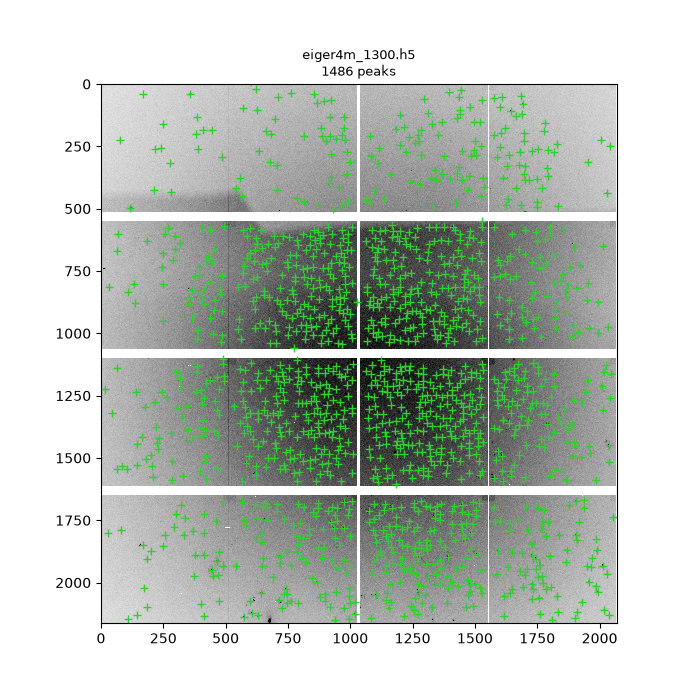

```python
plt.close('all')   # figures of previous runs of the cells (interactive figures pile up in memory)
MW.print_parameters(pcfg, 'peaksearch')
TEST_IMAGE = None     # None: image of the middle of the map; or an image index

test_image = pcfg['run']['test_image_index'] if TEST_IMAGE is None else TEST_IMAGE
imagefile = PB.image_path(pcfg, test_image)
res = PB.peaksearch_image(imagefile, PB.params_from_config(pcfg, writefiles=False))
PB.print_result(res)

imagedata = PB.read_image(imagefile, pcfg['scan']['CCDLabel'])
ax = PB.plot_peaks(imagedata, res[2], pcfg['exclusion_boxes'], title=imagefile.name)
plt.show()
```

## all images

Long computations: a progress bar shows the progress (on the cluster: status line updated every 30 s). On the cluster, if you interrupt the waiting (stop button), the job goes on: run the cell again to wait for its end (it is not submitted again).

```
2601 images found in /data/visitor/<proposal>/bm32/<date>/RAW_DATA/<sample>/<dataset>/scan0001
Configuration OK
peaksearch: 2601 files
job folder: /data/visitor/<proposal>/bm32/<date>/PROCESSED_DATA/<sample>/<dataset>/scan0001/slurm_jobs/peaksearch_<dataset>_20261006_151856
2601 images, 3 job(s) of 192 cpus on magnifix3, time limit 00:20:00
peak lists -> /data/visitor/<proposal>/bm32/<date>/PROCESSED_DATA/<sample>/<dataset>/scan0001/corfiles
to submit from a terminal (jupyter-slurm):
    sbatch /data/visitor/<proposal>/bm32/<date>/PROCESSED_DATA/<sample>/<dataset>/scan0001/slurm_jobs/peaksearch_<dataset>_20261006_151856/job.slurm
Submitted batch job 37196964
```

```
job 37196964 on magnifix3: finished | results 3/3 | images done: 867/867 867/867 867/867 | waiting for 60 s
```

```
2601 results / 2601 image files
nb of treated images : 2601
nb of peaks per image: min 709, mean 1398.4, max 1798
results saved at 2026-10-06 15:19:57 in
/data/visitor/<proposal>/bm32/<date>/PROCESSED_DATA/<sample>/<dataset>/scan0001/corfiles/peaksearch_peaks.pickle
peaksearch done
nb of treated images : 2601
nb of peaks per image: min 709, mean 1398.4, max 1798
```

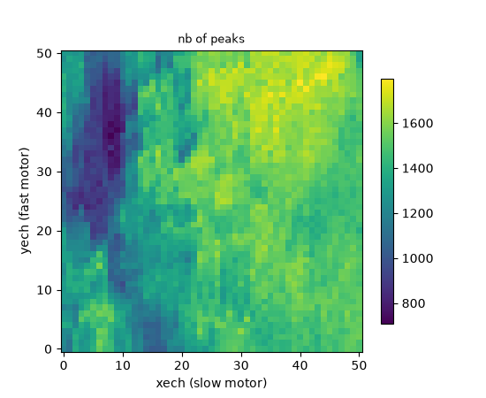

```python
plt.close('all')   # figures of previous runs of the cells (interactive figures pile up in memory)
peaks = MW.run_step('peaksearch', pcfg, execution, nb_cpus=NB_CPUS, machine=SLURM_MACHINE, redo=REDO)

if peaks is not None:
    summary_peaks = PB.summarize_results(peaks, pcfg['scan']['mapdims'])
    MW.plot_map(summary_peaks['nbpeaks2D'], pcfg, 'nb of peaks')
    plt.show()
```

# STEP 4: INDEXATION

## test on one image

A good result: grain 0 with **at least ~20 indexed spots** and a **matching rate above ~30 %** (green). If not:

- check `KEY_MATERIAL` and the calibration file (STEP 2)
- more spots for the indexation (weak patterns): `INDEXING = {'MinimumNumberMatches': 6}`; larger angular tolerance: `INDEXING = {'AngleTolLUT': 0.5}`

The parameters are printed first: their names can be used in `INDEXING` (SETTINGS).

```python
MW.print_parameters(icfg, 'indexing')
iparams = IB.params_from_config(icfg, useinternalmultiprocessing=False, writefitfile=False)
res = IB.index_refine(IB.corfile_path(icfg, test_image), iparams)
IB.print_result(res)
```

```
indexing parameters (/data/visitor/<proposal>/bm32/<date>/PROCESSED_DATA/<sample>/<dataset>/scan0001/configs/indexing.yaml), names usable in INDEXING = {name: value}:
   'e_min'                           : 5
   'e_max'                           : 22
   'e_max_MR'                        : 19
   'nbGrainstoFind'                  : 5
   'depth'                           : 0
   'MatchingRate_List'               : [2, 2, 2]
   'MIN_NUMBERSPOTS_FOR_INDEXING'    : 6
   'MAX_NUMBERSPOTS_FOR_INDEXING'    : 10000
   'MAXNBSPOTS'                      : None
   'crudeMReval'                     : True
   'maxnbspots_MReval'               : 10000
   'stop_Nb_Matches'                 : 40
   'central spots indices'           : [0, 1, 2, 3, 4, 5] ... (25 values)
   'AngleTolLUT'                     : 0.2
   'nlutmax'                         : 4
   'NBMAXPROBED'                     : 30
   'MATCHINGRATE_ANGLE_TOL'          : 0.2
   'MinimumMatchingRate'             : 5
   'MinimumNumberMatches'            : 10
   'CheckOrientation'                : None
   'MATCHINGRATE_THRESHOLD_IAL'      : 2
   'GuessedUBMatrix'                 : None
   'list matching tol angles'        : [0.2, 0.15, 0.1]
   'UseIntensityWeights'             : False
   'nbSpotsToIndex'                  : 10000
   'MinimumNbIndexedSpots'           : 20
   'LargestMeanPixelResidue'         : 0.6
image index 1300
grain 0: Nb indexed Reflections: 23, Matching Rate 45.10%
UB matrix found: [[0.7507549786334173, -0.6251585925779548, 0.2286862726199234], [0.6280062795624126, 0.5544250595776562, -0.54407294457894], [0.21197865214792166, 0.5496979243717505, 0.8059040955785638]]

grain 1: Nb indexed Reflections: 25, Matching Rate 45.45%
UB matrix found: [[0.875068493236297, -0.418410290433464, -0.24927780291106974], [0.48149888707339844, 0.6822893531155262, 0.5463028138660297], [-0.05845723015452374, -0.5963543367329638, 0.7968789150480379]]

grain 2: Nb indexed Reflections: 16, Matching Rate 28.07%. These (poor?) results may be not reliable
UB matrix found: [[0.7803949498155653, 0.6035225197247015, 0.1766458187063163], [-0.2949290857539507, 0.5989415656285989, -0.7416502163766839], [-0.5517217709355832, 0.5252246344558559, 0.643152511277597]]

grain 3: Nb indexed Reflections: 18, Matching Rate 33.96%. These (poor?) results may be not reliable
UB matrix found: [[0.8907812283810324, 0.40414643228432096, 0.23167107714756588], [-0.4203425878206056, 0.9086879770509271, 0.019395929333627274], [-0.20098367821047805, -0.11276972680039793, 0.9726013619053847]]

grain 4: Nb indexed Reflections: 14, Matching Rate 26.92%. These (poor?) results may be not reliable
UB matrix found: [[0.8872795300587637, 0.41867905486987145, 0.21108906931774185], [-0.4259087011966541, 0.9074184583433472, -0.009985548250029749], [-0.1955533900237981, -0.08332026991534967, 0.9774245168859323]]

Info:   Treated by IndexSpotsSet().
```

## all images

```
2601 .cor files found in /data/visitor/<proposal>/bm32/<date>/PROCESSED_DATA/<sample>/<dataset>/scan0001/corfiles
Configuration OK
indexing: 2601 files
job folder: /data/visitor/<proposal>/bm32/<date>/PROCESSED_DATA/<sample>/<dataset>/scan0001/slurm_jobs/indexing_<dataset>_20261006_152312
2601 .cor files, 3 job(s) of 192 cpus on magnifix3, time limit 00:20:00
.fit files -> /data/visitor/<proposal>/bm32/<date>/PROCESSED_DATA/<sample>/<dataset>/scan0001/fitfiles_MgO
to submit from a terminal (jupyter-slurm):
    sbatch /data/visitor/<proposal>/bm32/<date>/PROCESSED_DATA/<sample>/<dataset>/scan0001/slurm_jobs/indexing_<dataset>_20261006_152312/job.slurm
Submitted batch job 37197136
```

```
job 37197136 on magnifix3: finished | results 3/3 | images done: 867/867 867/867 867/867 | waiting for 120 s
```

```
2601 results / 2601 .cor files
nb of treated datasets : 2601
number of non indexed datasets 0
number of indexed (or updated) datasets 2601
allresults saved at 2026-10-06 15:25:13 in
/data/visitor/<proposal>/bm32/<date>/PROCESSED_DATA/<sample>/<dataset>/scan0001/fitfiles_MgO/allresults_MgO.pickle
indexing done
nb of treated datasets : 2601
number of non indexed datasets 0
number of indexed (or updated) datasets 2601
```

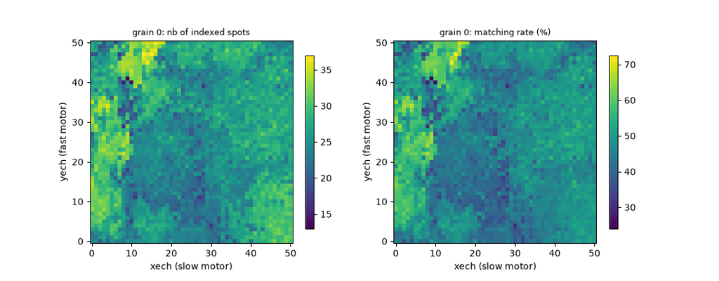

```python
plt.close('all')   # figures of previous runs of the cells (interactive figures pile up in memory)
fits = MW.run_step('indexing', icfg, execution, nb_cpus=NB_CPUS, machine=SLURM_MACHINE, redo=REDO,
                   show_only=show_only)

if fits is not None:
    summary = IB.summarize_results(fits, icfg['scan']['mapdims'])
    fig, axes = plt.subplots(1, 2, figsize=(11, 4.3))
    MW.plot_map(summary['Nbindexedimages2D'], icfg, 'grain 0: nb of indexed spots', ax=axes[0])
    MW.plot_map(summary['MRindexedimages2D'], icfg, 'grain 0: matching rate (%)', ax=axes[1])
    plt.show()
```

# STEP 5: MAPS

## quality of the indexation

All grains found in each image (`_g0.fit`, `_g1.fit` ...) are read; at each point, the **best grain** (most indexed spots) is used. `g0` is only the first grain found, not always the best one.

A point is **not reliable** (black in the next maps) if its best grain has too few indexed spots or a large mean pixel deviation (difference between measured and computed spot positions). The map *why masked* and the histograms show the reason and the thresholds (red lines). If many points are masked by a deviation just above the threshold, the threshold may be too strict for these data (e.g. calibration measured at another temperature): set `MAX_PIXEL_DEVIATION` below. Default thresholds: `configs/indexing.yaml` (`postprocess:` section).

```
[interactive widget (ipywidgets)]
```

```
[interactive widget (ipywidgets)]
```

```
2601 .fit files of grain 0 read / 2601 map points (11 s)
```

```
[interactive widget (ipywidgets)]
```

```
2566 .fit files of grain 1 read / 2601 map points (11 s)
```

```
[interactive widget (ipywidgets)]
```

```
2460 .fit files of grain 2 read / 2601 map points (10 s)
```

```
[interactive widget (ipywidgets)]
```

```
2232 .fit files of grain 3 read / 2601 map points (9 s)
1826 .fit files of grain 4 read / 2601 map points (8 s)
1021 reliable points / 2601 (39%), best grain of each point (g0 is the best grain at 2170 points)
masked: 1578 with mean pixel deviation > 0.6, 14 with < 20 indexed spots, 0 not indexed
many points have a deviation > 0.6 pixel (median 0.67): the threshold may be too strict for these data (e.g. calibration at another temperature, strained sample): try e.g. MAX_PIXEL_DEVIATION = 1.0
```

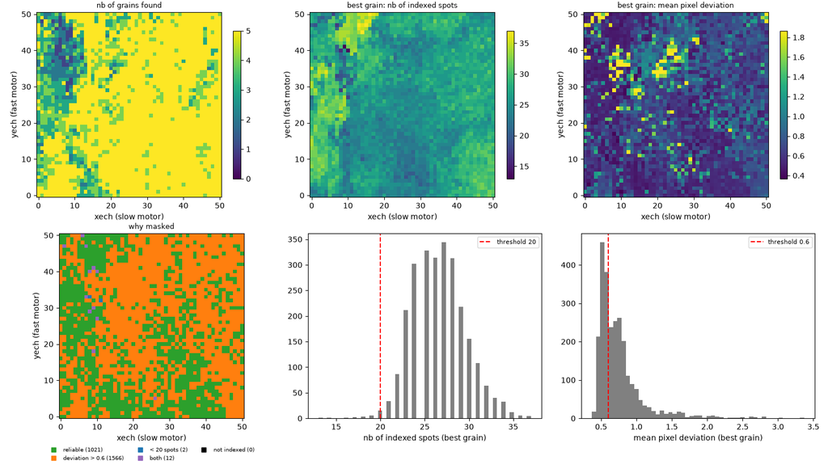

```python
plt.close('all')   # figures of previous runs of the cells (interactive figures pile up in memory)
MIN_INDEXED_SPOTS = None     # None: MinimumNbIndexedSpots of indexing.yaml
MAX_PIXEL_DEVIATION = None   # None: LargestMeanPixelResidue of indexing.yaml

grains = MW.load_grains(icfg)
fig, mask = MW.quality_maps(grains, icfg, MIN_INDEXED_SPOTS, MAX_PIXEL_DEVIATION)
plt.show()
```

## orientation: inverse pole figure (IPF) maps

Color = crystal direction along the sample axis x, y or z (color key on the right), for the best grain of each point. Same color = same orientation. Black: points not reliable (see above).

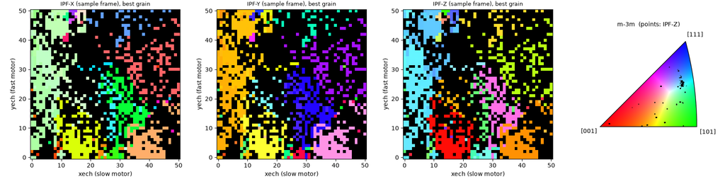

```python
fig = MW.orientation_maps(grains, icfg, mask=mask)
plt.show()
```

## grains (segmentation)

Grains are groups of neighbouring points with a misorientation smaller than `GRAIN_THRESHOLD` (deg), using all grains found in each image. Then:

- **KAM** (kernel average misorientation): local misorientation between neighbours (deformation, sub-grain boundaries)
- **GROD** (grain reference orientation deviation): misorientation to the reference orientation of the grain

```
materials ['MgO'] -> symmetry: cubic
ClusterResult(78 clusters, threshold=1.0°, symmetry=cubic, mode=all_connected_8): 10942/11685 matrices assigned
  Cluster   0:  3152 matrices,  1995 pixels, mean (row, col)=( 17.2,  26.0), ref img   894, std=0.81°, max dev=3.51°, grains [0, 1, 2, 3, 4]
  Cluster   1:   767 matrices,   766 pixels, mean (row, col)=( 38.6,  33.3), ref img  2022, std=0.07°, max dev=0.75°, grains [0, 1, 2, 3, 4]
  Cluster   2:   722 matrices,   721 pixels, mean (row, col)=( 31.1,  17.2), ref img  1598, std=0.07°, max dev=0.54°, grains [0, 1, 2, 3, 4]
  Cluster   3:   569 matrices,   569 pixels, mean (row, col)=( 27.2,  17.0), ref img  1394, std=0.04°, max dev=0.40°, grains [0, 1, 2, 3, 4]
  Cluster   4:   474 matrices,   465 pixels, mean (row, col)=( 41.9,  35.3), ref img  2177, std=0.08°, max dev=0.71°, grains [0, 1, 2, 3, 4]
  Cluster   5:   414 matrices,   414 pixels, mean (row, col)=( 16.1,  11.6), ref img   828, std=0.02°, max dev=0.16°, grains [0, 1, 2, 3, 4]
  Cluster   6:   409 matrices,   409 pixels, mean (row, col)=( 40.5,  10.0), ref img  2050, std=0.03°, max dev=0.22°, grains [0, 1, 2, 3, 4]
  Cluster   7:   405 matrices,   405 pixels, mean (row, col)=( 19.9,  19.8), ref img  1040, std=0.09°, max dev=0.45°, grains [0, 1, 2, 3, 4]
  Cluster   8:   288 matrices,   288 pixels, mean (row, col)=( 44.5,  13.2), ref img  2257, std=0.05°, max dev=0.35°, grains [0, 1, 2, 3, 4]
  Cluster   9:   280 matrices,   279 pixels, mean (row, col)=( 31.5,  45.5), ref img  1627, std=0.10°, max dev=0.84°, grains [0, 1, 2, 3, 4]
  ... and 68 more clusters
```

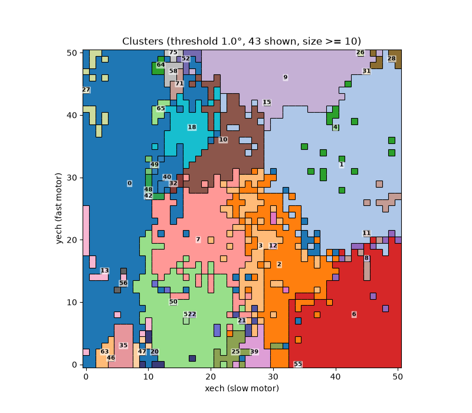

```python
plt.close('all')   # figures of previous runs of the cells (interactive figures pile up in memory)
GRAIN_THRESHOLD = 1.0    # deg, larger: fewer grains
MIN_GRAIN_SIZE = 10      # min nb of points of a grain

result, analyzer = MW.segmentation(icfg, threshold=GRAIN_THRESHOLD, min_cluster_size=MIN_GRAIN_SIZE)
OC.print_cluster_summary(result, analyzer, nb_max=10)
fig, ax = MW.plot_clusters(result, analyzer, icfg, min_size=MIN_GRAIN_SIZE)
plt.show()
```

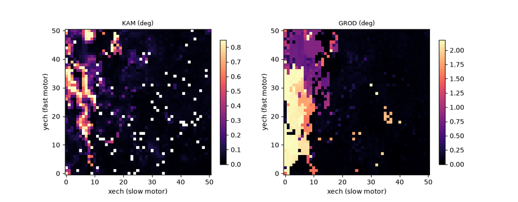

```python
kam = OC.compute_kam(analyzer, result, symmetry=result.symmetry)
grod = OC.compute_grod_map(result, analyzer)

fig, axes = plt.subplots(1, 2, figsize=(11, 4.3))
MW.plot_map(kam, icfg, 'KAM (deg)', ax=axes[0], cmap='magma', vmin=0, vmax=np.nanpercentile(kam, 98))
MW.plot_map(grod, icfg, 'GROD (deg)', ax=axes[1], cmap='magma', vmin=0, vmax=np.nanpercentile(grod, 98))
plt.show()
```

## more

- strain, lattice parameters, misorientation to a reference point: `../indexation/2_postprocess_maps.ipynb`
- interactive browser of the grains (properties of each grain): `../indexation/3_segmentation_grains.ipynb`

with `CONFIG` = the indexation settings file printed below

```python
print("CONFIG = '%s'" % icfg['configfile'])
```

```
CONFIG = '/data/visitor/<proposal>/bm32/<date>/PROCESSED_DATA/<sample>/<dataset>/scan0001/configs/indexing.yaml'
```

# STEP 6 (option): the same analysis for a series of maps

The maps of `SERIES` are analysed with the settings files of the map of STEP 1-4 (peak search, indexation), one after the other (each one on the cluster if available). Maps already done are skipped.

```python
SERIES = []    # scan indices of the table of STEP 1, e.g. [1240, 1259, 1278]
# or all the maps whose name contains a text:   SERIES = [i for i in maps.index if 'ZONE3' in maps.loc[i, 'dataset']]

series = {}
if SERIES:
    series = MW.process_maps(maps, SERIES, info, KEY_MATERIAL, detfile, output_root=OUTPUT_ROOT,
                             execution=execution, nb_cpus=NB_CPUS, machine=SLURM_MACHINE, redo=REDO)
```

```python
plt.close('all')   # figures of previous runs of the cells (interactive figures pile up in memory)
# nb of indexed spots (grain 0) of the maps of the series
if series:
    ncols = min(4, len(series))
    nrows = int(np.ceil(len(series) / ncols))
    fig, axes = plt.subplots(nrows, ncols, figsize=(4.2 * ncols, 3.6 * nrows), squeeze=False)
    for ax, (index, cfg_i) in zip(axes.flat, series.items()):
        res_i = IB.load_allresults(MW._results_file('indexing', cfg_i))['dict_results_summary']
        MW.plot_map(res_i['Nbindexedimages2D'], cfg_i, f"{index}: {cfg_i['name']}", ax=ax)
    for ax in axes.flat[len(series):]:
        ax.axis('off')
    fig.tight_layout()
    plt.show()
```